# GCA: An R package for genetic connectedness analysis using pedigree and genomic data

## Introduction

Genetic connectedness quantifies the extent of linkage between individuals across management units. The concept of genetic connectedness can be extended to measure the connectedness level between training and testing sets in whole-genome prediction. We developed the genetic connectedness analysis R package, GCA, which utilizes pedigree or genomic data to measure the connectedness between individuals across units.

## Connectedness Statistics

The connectedness statistics implemented in this R package can be classified into two core functions: prediction error variance (PEV) and variance of unit effect estimates (VE). The PEV-derived metrics include prediction error variance of differences (PEVD), coefficient of determination (CD), and prediction error correlation (r). These PEV-derived metrics can be summarized at the unit level as the average PEV within and across units (GrpAve), average PEV of all pairwise differences between individuals across units (IdAve), or using a contrast vector (Contrast). VE-derived metrics include variance of differences in management unit effects (VED), coefficient of determination of VED (CDVED), and connectedness rating (CR). Three correction factors accounting for the number of fixed effects can be applied for each VE-derived metric. These include no correction (0), correcting for one fixed effect (1), and correcting for two or more fixed effects (2). The R code is integrated with C++ to improve computational speed using the Rcpp package [1]. We expect this R package provides a comprehensive and effective tool for genetic connectedness analysis and whole-genome prediction. A comprehensive list of all connectedness statistics implemented in this R package can be summarized as following. The details of these connectedness statistics can be found in the [paper](https://www.biorxiv.org/content/10.1101/696419v2) [2].

[interactive chart not shown]

Figure 1: An overview of connectedness statistics implemented in the GCA R package.

## Application of the GCA package

### Installing the GCA package from GitHub

```r
install.packages("devtools")
library(devtools)
install_github('HaipengU/GCA')
```

### Load all packages used in this vignette.

```r
library(BGLR)
library(corrplot)
library(GCA)
library(ggplot2)
library(gridExtra)
```

### Data preparation

The simulated dataset `GCcattle` contains two objects `cattle.pheno` and `cattle.W`, which include phenotypic and marker information, respectively. The details can be obtained by typing `?GCcattle`.

```r
data(GCcattle)
dim(cattle.pheno) # phenotypes + fixed effects
```

```
## [1] 2500    6
```

```r
dim(cattle.W) # marker matrix
```

```
## [1]  2500 10000
```

The heritability of simulated phenotype was set to 0.6 with $\sigma^2_a$ = 0.6 and $\sigma^2_e$ = 0.4.

```r
sigma2a <- 0.6 # additive genetic variance
sigma2e <- 0.4 # residual variance
```

Below we construct the incidence matrix of fixed effects and a genomic relationship matrix.

```r
X2 <- model.matrix(~ -1 + factor(cattle.pheno$Unit) + factor(cattle.pheno$Sex)) # incidence matrix of unit effect and sex
G <- computeG(cattle.W, maf = 0.05) # genomic relationship matrix; markers with minor allele frequency (maf)
```

```
## Genomic relationship matrix has been computed. Number of SNPs removed: 99
```

```r
                                    # less than 0.05 are removed
```

### Available connectedness statistics in the GCA package

The following section lists all available connectedness statistics in the GCA package, which are available by setting the argument of `statistic`.

- PEVD_IdAve : Pairwise individual average PEVD, the optional argument of ‘scale’ is available.
- PEVD_GrpAve : Group average PEVD, the optional arguments of ‘scale’ and ‘diag’ are available.
- PEVD_contrast: Contrast PEVD, the optional argument of ‘scale’ is available.
- CD_IdAve : Pairwise individual CD.
- CD_GrpAve : Group average CD, the optional argument of ‘diag’ is available.
- CD_contrast : Contrast CD.
- r_IdAve : Pairwise individual r.
- r_GrpAve : Group average r, the optional argument of ‘diag’ is available.
- r_contrast : Contrast r.
- VED0 : Variance of estimate of unit effects differences. The optional argument of ‘scale’ is available.
- VED1 : Variance of estimate of unit effects differences with the correction of unit effect. The optional argument of ‘scale’ is available.
- VED2 : Variance of estimate of unit effects differences with the correction of unit effect and additional fixed effects. The additional argument of ‘Uidx’ is required to inform the last column number of units in the incidence matrix corresponding to fixed effects and the optional argument of ‘scale’ is available.
- CDVED0 : Coefficient of determination of VED, the optional argument of ‘diag’ is available.
- CDVED1 : Coefficient of determination of VED with the correction of unit effect. The optional argument of ‘diag’ is available.
- CDVED2 : Coefficient of determination of VED with the correction of unit effect and additional fixed effects. The additional argument of ‘Uidx’ is required to inform the last column number of units in the incidence matrix corresponding to fixed effects and the optional argument of ‘diag’ is available.
- CR0 : Connectedness rating.
- CR1 : Connectedness rating with the correction of unit effect.
- CR2 : Connectedness rating with the correction of unit effect and additional fixed effects. The additional argument of ‘Uidx’ is required to inform the last column number of units in the incidence matrix corresponding to fixed effects.

### Examples of connectedness measures across units

Below we list some examples of connectedness statistics available in the GCA package. The `gca` function is the main engine in the GCA package. The usage and detailed arguments of the gca function are explained below.

```r
gca(Kmatrix, Xmatrix, sigma2a, sigma2e, MUScenario, statistic, NumofMU,
    Uidx = NULL, scale = TRUE, diag = TRUE)
```

- Kmatrix Genetic relationship matrix constructed from either pedigree or genomics.
- Xmatrix: Fixed effects incidence matrix excluding intercept. The first column of the Xmatrix should start with unit effects followed by other fixed effects if applicable.
- sigma2a and sigma2e: Estimates of additive genetic and residual variances, respectively.
- MUScenario: A vector of fixed factor units.
- statistic: Choice of connectedness statistic. Available options include
  1. PEV-derived functions: PEVD_IdAve, PEVD_GrpAve, PEVD_contrast, CD_IdAve, CD_GrpAve, CD_contrast, r_IdAve, r_GrpAve, and r_contrast.
  2. VE-derived functions: VED0, VED1, VED2, CDVED0, CDVED1, CDVED2, CR0, CR1, and CR2.
- NumofMU: Return either pairwise unit connectedness (Pairwise) or overall connectedness across all units (Overall).
- Uidx: An integer indicating the last column number of units in the Xmatrix. This Uidx is required for VED2, CDVED2, and CR2 statistics. The default is NULL.
- scale (logical): Should sigma2a be used to scale statistic (i.e., PEVD_IdAve, PEVD_GrpAve, PEVD_contrast, VED0, VED1, and VED2) so that connectedness is independent of measurement unit? The default is TRUE.
- diag (logical): Should the diagonal elements of the PEV matrix (i.e., PEVD_GrpAve, CD_GrpAve, and r_GrpAve) or the K matrix (CDVED0, CDVED1, and CDVED2) be included? The default is TRUE.

#### PEV-derived statistic: PEVD_GrpAve (pairwise vs. overall)

The following example illustrates the group average PEVD between all units. Based on the results, units 1 and 8 are the most connected (PEVD_GrpAve = 0.0156) and the least connected units are units 4 and 6 (PEVD_GrpAve = 0.0571). The PEVD statistic ranges from 0 to 1, with the smaller value indicates more connectedness.

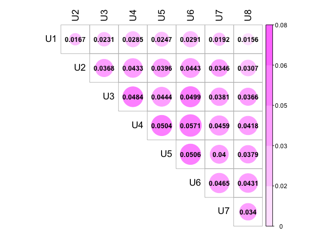

```r
PEVD_GrpAve <- gca(Kmatrix = G, Xmatrix = X2, sigma2a = sigma2a, sigma2e = sigma2e,
                  MUScenario = as.factor(cattle.pheno$Unit), statistic = 'PEVD_GrpAve',
                  NumofMU = 'Pairwise')
# remove NAs in diagnol to make plot
diag(PEVD_GrpAve) <- 0
corrplot(PEVD_GrpAve, is.corr = FALSE, method ="circle", type = "upper",
         diag = F, number.cex = 7 / ncol(PEVD_GrpAve), col = cm.colors(10), cl.lim = c(0, 0.08),
         number.digits = 4, mar = c(0,1,1,1), addCoef.col = "black",
         tl.col = "black", tl.srt = 90, tl.cex = 1.2)
```

Alternatively, the `gca` function can return an overall connectedness, which averages all pairwise PEVD_GrpAve between units by setting `NumofMU` to `'Overall'`.

```r
PEVD_GrpAve_Overall <- gca(Kmatrix = G, Xmatrix = X2, sigma2a = sigma2a,
                           sigma2e = sigma2e, MUScenario = as.factor(cattle.pheno$Unit),
                           statistic = 'PEVD_GrpAve', NumofMU = 'Overall')
PEVD_GrpAve_Overall
```

```
## [1] 0.03752627
```

Following the above example, the pairwise individual average PEVD and contrast PEVD can be easily calculated by changing the argument `statistic` to `'PEVD_IdAve'` and `'PEVD_contrast'`, respectively.

#### PEV-derived statistic: CD_GrpAve

The group average CD statistic between units is shown in the following example. The most connected units was found between units 1 and 7 (CD_GrpAve = 0.7096). On the other hand, the least connected design was found between units 1 and 6 (CD_GrpAve = 0.6494). The larger CD statistics indicates the greater connectedness. These results are different from the findings according to PEVD_GrpAve, because CD penalizes connectedness measures for reduced genetic variability [3, 4]. Similarly, the pairwise individual average CD and contrast CD can be calculated by changing the argument `statistic` to `'CD_IdAve'` and `'CD_contrast'`, respectively.

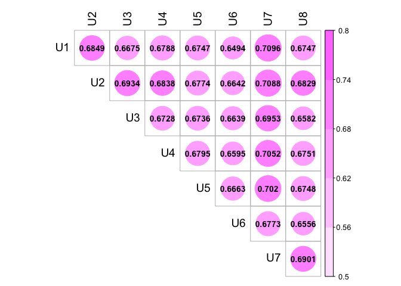

```r
CD_GrpAve <- gca(Kmatrix = G, Xmatrix = X2, sigma2a = sigma2a, sigma2e = sigma2e,
                MUScenario = as.factor(cattle.pheno$Unit), statistic = 'CD_GrpAve',
                NumofMU = 'Pairwise')
# replace NAs in diagnol to make plot
diag(CD_GrpAve) <- min(CD_GrpAve, na.rm = T)
corrplot(CD_GrpAve, is.corr = FALSE, method ="circle", type = "upper",
         diag = F, number.cex = 7 / ncol(CD_GrpAve), col = cm.colors(10),
         number.digits = 4, mar = c(0,1,1,1), addCoef.col = "black",
         tl.col = "black", tl.srt = 90, tl.cex = 1.2, cl.lim = c(0.5, 0.8))
```

#### VE-derived statistic: VED

The following example illustrates three VED statistics of VED0, VED1, and VED2 when sex and unit effects are both included in the model. Here, the smaller value indicates the greater connectedness. We can see that the most connected units across three VED statistics are found between units 1 and 8 (VED0 = 0.0205, VED1 = 0.0156, VED2 = 0.0156). On the other hand, units 4 and 6 (VED0 = 0.0728, VED1 = 0.0571, VED2 = 0.0571) shows the least connectedness.

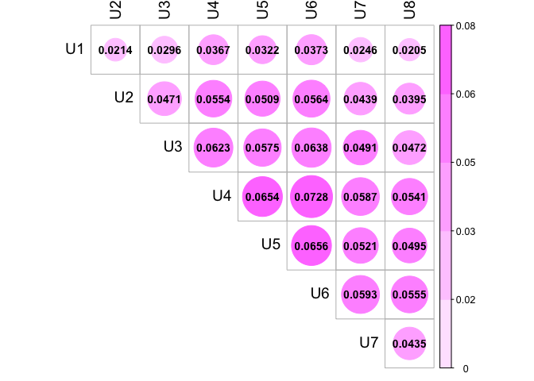

```r
VED0  <- gca(Kmatrix = G, Xmatrix = X2, sigma2a = sigma2a, sigma2e = sigma2e,
             MUScenario = as.factor(cattle.pheno$Unit), statistic = 'VED0',
             NumofMU = 'Pairwise')
VED1  <- gca(Kmatrix = G, Xmatrix = X2, sigma2a = sigma2a, sigma2e = sigma2e,
             MUScenario = as.factor(cattle.pheno$Unit), statistic = 'VED1',
             NumofMU = 'Pairwise')
VED2  <- gca(Kmatrix = G, Xmatrix = X2, sigma2a = sigma2a, sigma2e = sigma2e,
               MUScenario = as.factor(cattle.pheno$Unit), statistic = 'VED2',
               NumofMU = 'Pairwise', Uidx = 8)
# replace NAs in diagnol to make plot
diag(VED0) <- diag(VED1) <- diag(VED2) <- floor(min(VED0, na.rm = T))
corrplot(VED0, is.corr =FALSE, method="circle", type = "upper",
         diag = F, number.cex = 7 / ncol(VED0), col = cm.colors(10),
         number.digits = 4, addCoef.col = "black", tl.col = "black",
         tl.srt = 90, tl.cex = 1.2, cl.lim = c(0, 0.08))
```

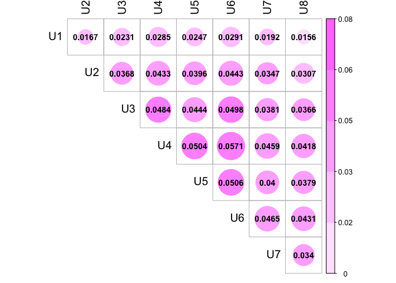

```r
corrplot(VED1, is.corr =FALSE, method="circle", type = "upper",
         diag = F, number.cex = 7 / ncol(VED1), col = cm.colors(10),
         number.digits = 4, addCoef.col = "black", tl.col = "black",
         tl.srt = 90, tl.cex = 1.2, cl.lim = c(0, 0.08))
```

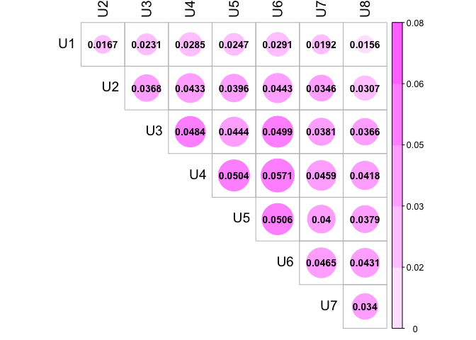

```r
corrplot(VED2, is.corr =FALSE, method="circle", type = "upper",
         diag = F, number.cex= 7 / ncol(VED2), col = cm.colors(10),
         number.digits = 4, addCoef.col = "black", tl.col = "black",
         tl.srt = 90, tl.cex = 1.2, cl.lim = c(0, 0.08))
```

#### VE-derived statistic: CDVED

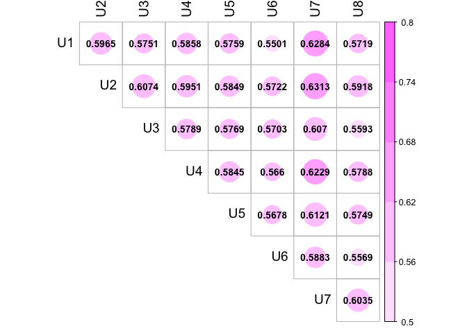

```r
CDVED0  <- gca(Kmatrix = G, Xmatrix = X2, sigma2a = sigma2a, sigma2e = sigma2e,
             MUScenario = as.factor(cattle.pheno$Unit), statistic = 'CDVED0',
             NumofMU = 'Pairwise')
CDVED1  <- gca(Kmatrix = G, Xmatrix = X2, sigma2a = sigma2a, sigma2e = sigma2e,
             MUScenario = as.factor(cattle.pheno$Unit), statistic = 'CDVED1',
             NumofMU = 'Pairwise')
CDVED2  <- gca(Kmatrix = G, Xmatrix = X2, sigma2a = sigma2a, sigma2e = sigma2e,
             MUScenario = as.factor(cattle.pheno$Unit), statistic = 'CDVED2',
             NumofMU = 'Pairwise', Uidx = 8)
# replace NAs in diagnol to make plot
diag(CDVED0) <- diag(CDVED1) <- diag(CDVED2) <- 0.5
corrplot(CDVED0, is.corr = FALSE, method ="circle", type = "upper",
         diag = F, number.cex = 7 / ncol(CDVED0), col = cm.colors(10),
         number.digits = 4, addCoef.col = "black", tl.col = "black",
         tl.srt = 90, tl.cex = 1.2, cl.lim = c(0.5, 0.8))
```

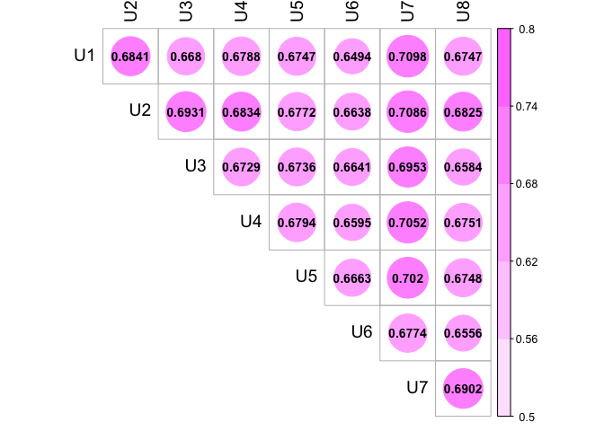

```r
corrplot(CDVED1, is.corr = FALSE, method ="circle", type = "upper",
         diag = F, number.cex = 7 / ncol(CDVED1), col = cm.colors(10),
         number.digits = 4, addCoef.col = "black", tl.col = "black",
         tl.srt = 90, tl.cex = 1.2, cl.lim = c(0.5, 0.8))
```

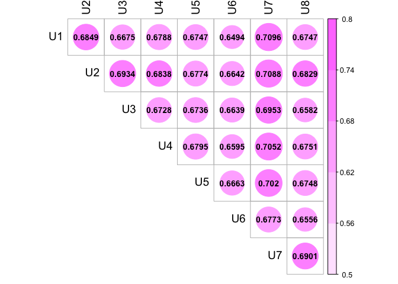

```r
corrplot(CDVED2, is.corr = FALSE, method ="circle", type = "upper",
         diag = F, number.cex = 7 / ncol(CDVED2), col = cm.colors(10),
         number.digits = 4, addCoef.col = "black", tl.col = "black",
         tl.srt = 90, tl.cex = 1.2, cl.lim = c(0.5, 0.8))
```

### Relationship between connectedness statistics

In this section, we calculate the correlation between PEV-based and VE-based connectedness statistics to compared with the results reported in Holmes et al. [5].

#### PEVD vs. VED0, VED1 and VED2

Using the statistics shown in the previous section, the relationships between PEVD_GrPAve and VED0, VED1, and VED2 are visualized via a correlation plot. The statistic PEVD showed a strong relationship with three VED statistics. The strongest relationship (a perfect positive correlation) showed between PEVD and VED2 when two fixed effects of unit effect and sex are corrected. All of these results are consistent with the results claimed in Holmes et al. [5].

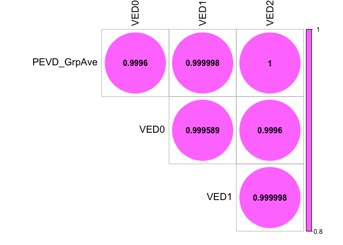

Figure 2: Correlation between PEVD_GrpAve and VED0, VED1, and VED2.

```r
df_PEVD_VED <- data.frame(PEVD_GrpAve = PEVD_GrpAve[upper.tri(PEVD_GrpAve)],
                          VED0 = VED0[upper.tri(VED0)],
                          VED1 = VED1[upper.tri(VED1)],
                          VED2 = VED2[upper.tri(VED2)])

corrplot(cor(df_PEVD_VED), method="circle", type = "upper",
         diag = F, number.cex= 4 / ncol(df_PEVD_VED), col = cm.colors(10),
         number.digits = 6, addCoef.col = "black", tl.col = "black",
         tl.srt = 90, tl.cex = 1.2, cl.lim = c(0.8, 1))
```

#### CD vs. CDVED0, CDVED1, and CDVED2

The CD_GrpAve statistic is compared with statistics of CDVED0, CDVED1, and CDVED2 in the following example when unit effect and sex are included in the model.

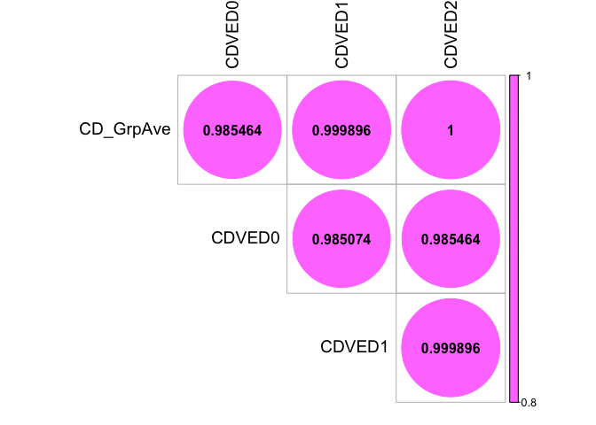

Figure 3: Correlation between CD_GrpAve and CDVED0, CDVED1, and CDVED2.

```r
df_CD_CDVED <- data.frame(CD_GrpAve = CD_GrpAve[upper.tri(CD_GrpAve)],
                          CDVED0 = CDVED0[upper.tri(CDVED0)],
                          CDVED1 = CDVED1[upper.tri(CDVED1)],
                          CDVED2 = CDVED2[upper.tri(CDVED2)])

corrplot(cor(df_CD_CDVED), method="circle", type = "upper",
         diag = F, number.cex= 4 / ncol(df_CD_CDVED), col = cm.colors(10),
         number.digits = 6, addCoef.col = "black", tl.col = "black",
         tl.srt = 90, tl.cex = 1.2, cl.lim = c(0.8, 1))
```

The correlation plot above showed the relationships between CD_GrPAve and CDVED0, CDVED1, and CDVED2. As we expected, analogous strong relationships are identified between CD_GrpAve and three CDVED statistics. An increased correlation is found when a correction factor is used to account for the sex and unit effects. A perfect positive correlation is identified between CD_GrpAve and CDVED2, where unit effect and sex are corrected in the model.

#### r vs. CR0, CR1, and CR2

The following example compared r_GrpAve with statistics of CR0, CR1, and CR2 when unit effect and sex are included in the model.The correlation plot below showed the relationships between r_GrPAve and CR0, CR1, and CR2. Unlike the stronger relationships between PEVD and VED0 and VED1 statistics above, r showed a weaker correlation with CR0 and CR1 statistics as reported in Holmes et al. [5]. An increased correlation between r_GrpAve and CR1 is found when the unit effect is accounted for using the correction factor. The statistic r_GrpAve is found to have a perfect positive correlation with CR2 when unit effect and sex are corrected in the model.

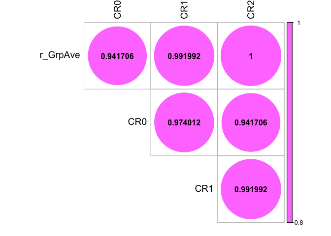

Figure 4: Correlation between r_GrpAve and CR0, CR1, and CR2.

```r
r_GrpAve <- gca(Kmatrix = G, Xmatrix = X2, sigma2a = sigma2a, sigma2e = sigma2e,
                  MUScenario = as.factor(cattle.pheno$Unit),
                statistic = 'r_GrpAve', NumofMU = 'Pairwise')
CR0  <- gca(Kmatrix = G, Xmatrix = X2, sigma2a = sigma2a, sigma2e = sigma2e,
             MUScenario = as.factor(cattle.pheno$Unit), statistic = 'CR0',
             NumofMU = 'Pairwise')
CR1  <- gca(Kmatrix = G, Xmatrix = X2, sigma2a = sigma2a, sigma2e = sigma2e,
             MUScenario = as.factor(cattle.pheno$Unit), statistic = 'CR1',
             NumofMU = 'Pairwise')
CR2  <- gca(Kmatrix = G, Xmatrix = X2, sigma2a = sigma2a, sigma2e = sigma2e,
               MUScenario = as.factor(cattle.pheno$Unit), statistic = 'CR2',
               NumofMU = 'Pairwise', Uidx = 8)
df_r_CR <- data.frame(r_GrpAve = r_GrpAve[upper.tri(r_GrpAve)],
                      CR0 = CR0[upper.tri(CR0)], CR1 = CR1[upper.tri(CR1)],
                      CR2 = CR2[upper.tri(CR2)])
corrplot(cor(df_r_CR), method = "circle", type = "upper",
         diag = F, number.cex= 4 / ncol(df_r_CR), col = cm.colors(10),
         number.digits = 6, addCoef.col = "black", tl.col = "black",
         tl.srt = 90, tl.cex = 1.2, cl.lim = c(0.8, 1))
```

### The connectedness between training and testing sets in the whole-genome prediction paradigm

In whole-genome prediction, the relatedness between training and testing sets is known to impact the prediction accuracy. In this section, the connectedness and prediction accuracy is estimated for each of 5 simulation scenarios in which we gradually increased the relatedness level between the training and testing sets by exchanging 0, 140, 210, 280, and 350 individuals. This was followed by investigating the relationship between the connectedness measures and prediction accuracies using correlation plots.

#### Estimate of connectedness

In this section, the connectedness levels of 5 simulated unit scenarios are estimated using `gca` function. Two statistics of PEVD_GrpAve and CD_GrpAve are used to quantify the connectedness measures.

```r
# Define a function using gca function in GCA
GC <- function(MU, Kmatrix, sigma2a, sigma2e, stat){
  X <- model.matrix(~ -1 + factor(MU))
  GCstat <- gca(Kmatrix, Xmatrix = X, sigma2a, sigma2e,
                MUScenario = as.factor(MU),
                statistic = stat, NumofMU = 'Overall')
  return(GCstat)
}
# 5 simulated unit scenarios
head(CattleSIM[, 7: 11])
```

```
##   MUSC1 MUSC2 MUSC3 MUSC4 MUSC5
## 1     1     1     1     2     2
## 2     1     2     2     2     2
## 3     1     1     1     1     1
## 4     1     1     1     1     1
## 5     1     1     1     1     1
## 6     1     1     1     1     1
```

```r
# PEVD_GrpAve
PEVD_GrpAve <- apply(CattleSIM[, 7: 11], 2, function(x) GC(x,
                     Kmatrix = G, sigma2a, sigma2e, stat = 'PEVD_GrpAve'))
print(PEVD_GrpAve)
```

```
##        MUSC1        MUSC2        MUSC3        MUSC4        MUSC5
## 0.0039430647 0.0018066760 0.0013236613 0.0010374891 0.0009192205
```

```r
# CD_GrpAve
CD_GrpAve <- apply(CattleSIM[, 7: 11], 2, function(x) GC(x,
                   Kmatrix = G, sigma2a, sigma2e, stat = 'CD_GrpAve'))
print(CD_GrpAve)
```

```
##     MUSC1     MUSC2     MUSC3     MUSC4     MUSC5
## 0.6679398 0.7586556 0.7626448 0.7503289 0.7140141
```

#### Estimate of prediction accuracy

The prediction accuracy for each of 5 simulated unit scenarios is estimated using cross-validation.

```r
# Define a function to estimate PA using BGLR package
PA <- function(df, MU, Iter, BurnIn){
  folds <- length(unique(MU))
  Cor_CV <- matrix(NA, nrow = folds, ncol = 1)
  for(fold in 1:folds){
    y <- df
    yNa <- y
    whichNa <- which(MU == fold)
    yNa[whichNa] <- NA
    fit.GBLUP <- BGLR(y = yNa, ETA = ETA_GBLUP, nIter = Iter, burnIn = BurnIn, verbose = F)
    Cor_CV[fold, 1] <- cor(fit.GBLUP$yHat[whichNa], y[whichNa])
  }
  return(mean(Cor_CV))
}
# Prediction accuracies
EVD <- eigen(G)
ETA_GBLUP <- list(list(V = EVD$vectors, d = EVD$values, model = 'RKHS'))
PASum <- apply(CattleSIM[, 7: 11], 2, function(x) PA(df = CattleSIM$Phen, MU = x, 6000, 2000))
```

#### Relationship between connectedness measures and prediction accuracies

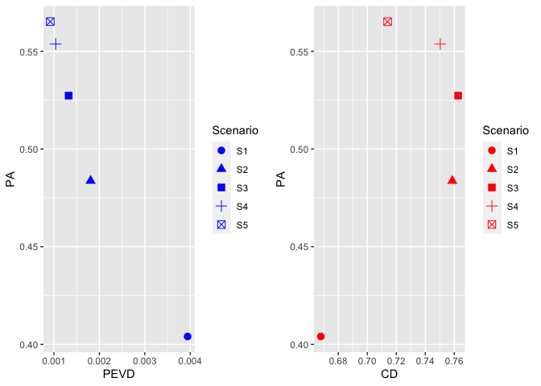

```r
dfPEVD <- data.frame("PEVD" = PEVD_GrpAve, 'PA' = PASum,
"Scenario" = paste('S', 1:5, sep = ''))
dfCD <- data.frame("CD" = CD_GrpAve, 'PA' = PASum,
"Scenario" = paste('S', 1:5, sep = ''))
p1 <- ggplot(dfPEVD,  aes(PEVD, PA)) + geom_point(aes(shape = factor(Scenario)), color = "blue", size = 3) +
  xlab("PEVD") + labs(shape="Scenario")
p2 <- ggplot(dfCD,  aes(CD, PA)) + geom_point(aes(shape = factor(Scenario)), color="red", size = 3) +
  labs(shape = "Scenario")
grid.arrange(p1, p2, nrow = 1, widths = c(10, 10), heights = 4)
```

## Authors

- Haipeng Yu (haipengyu@vt.edu)
- Gota Morota (morota@vt.edu)

## References

1. Eddelbuettel D, François R. Rcpp: Seamless R and C++ integration. Journal of Statistical Software. 2011;40:1–18. doi:10.18637/jss.v040.i08.

2. Yu H, Morota G. GCA: An r package for genetic connectedness analysis using pedigree and genomic data. bioRxiv. 2019. doi:10.1101/696419.

3. Yu H, Spangler ML, Lewis RM, Morota G. Genomic relatedness strengthens genetic connectedness across management units. G3: Genes, Genomes, Genetics. 2017;7:3543–56.

4. Yu H, Spangler ML, Lewis RM, Morota G. Do stronger measures of genomic connectedness enhance prediction accuracies across management units? Journal of Animal Science. 2018;96:4490–500.

5. Holmes JB, Dodds KG, Lee MA. Estimation of genetic connectedness diagnostics based on prediction errors without the prediction error variance–covariance matrix. Genetics Selection Evolution. 2017;49:29.